# DAS Project 2 - Group 13

# Introduction

This project analyses data from the Coffee Quality Database (CQD), which contains information on coffee batches and their quality-related characteristics. The aim is to investigate which features of coffee, such as aroma, flavor, acidity, defects and altitude, influence whether a batch is classified as Good or Poor.

To answer this question, the dataset is first cleaned and explored using descriptive summaries and visualisations. A generalised linear model (GLM) is then used to examine how these variables are associated with coffee quality classification.

# Data Cleaning

```r
library(tidyverse)

coffee <- read_csv("dataset13.csv", show_col_types = FALSE)
```

```r
glimpse(coffee)
```

```
Rows: 1,145
Columns: 8
$ country_of_origin    <chr> "Myanmar", "Uganda", "Ethiopia", "Mexico", "Burun…
$ aroma                <dbl> 7.25, 8.33, 8.42, 7.17, 7.75, 7.92, 7.92, 7.83, 7…
$ flavor               <dbl> 7.42, 7.92, 8.00, 7.08, 7.67, 7.75, 7.83, 7.67, 6…
$ acidity              <dbl> 7.50, 7.92, 8.00, 7.25, 7.50, 7.75, 7.67, 7.58, 7…
$ category_two_defects <dbl> 4, 1, 7, 3, 5, 0, 1, 2, 2, 1, 0, 8, 0, 2, 0, 0, 2…
$ altitude_mean_meters <dbl> 1219.20, 1600.00, 1700.00, 1300.00, 1880.00, 1400…
$ harvested            <dbl> 2015, 2013, 2014, 2012, 2012, 2014, NA, 2015, 201…
$ Qualityclass         <chr> "Poor", "Good", "Good", "Poor", "Good", "Good", "…
```

```r
summary(coffee)
```

```
 country_of_origin      aroma           flavor         acidity
 Length:1145        Min.   :0.000   Min.   :0.000   Min.   :0.000
 Class :character   1st Qu.:7.420   1st Qu.:7.330   1st Qu.:7.330
 Mode  :character   Median :7.580   Median :7.580   Median :7.500
                    Mean   :7.571   Mean   :7.521   Mean   :7.536
                    3rd Qu.:7.750   3rd Qu.:7.750   3rd Qu.:7.750
                    Max.   :8.750   Max.   :8.670   Max.   :8.580

 category_two_defects altitude_mean_meters   harvested    Qualityclass
 Min.   : 0.000       Min.   :     1       Min.   :2010   Length:1145
 1st Qu.: 0.000       1st Qu.:  1100       1st Qu.:2012   Class :character
 Median : 2.000       Median :  1311       Median :2014   Mode  :character
 Mean   : 3.673       Mean   :  1851       Mean   :2014
 3rd Qu.: 5.000       3rd Qu.:  1600       3rd Qu.:2015
 Max.   :55.000       Max.   :190164       Max.   :2018
                      NA's   :201          NA's   :60
```

```r
colSums(is.na(coffee))
```

```
   country_of_origin                aroma               flavor
                   0                    0                    0
             acidity category_two_defects altitude_mean_meters
                   0                    0                  201
           harvested         Qualityclass
                  60                    0
```

```r
sum(duplicated(coffee))
```

```
[1] 1
```

```r
coffee <- coffee %>%
  distinct() %>%
  mutate(
    Qualityclass = as.factor(Qualityclass),
    country_of_origin = as.factor(country_of_origin)
  )
```

The dataset was inspected using `glimpse()` and `summary()` to understand the structure and distributions of the variables. Missing values were checked using `colSums(is.na())`, and duplicate rows were identified using `duplicated()`. Duplicate rows were removed to improve data quality before analysis.

```r
coffee_clean <- coffee %>%
  filter(!is.na(country_of_origin),
         !is.na(aroma),
         !is.na(flavor),
         !is.na(acidity),
         !is.na(category_two_defects),
         !is.na(altitude_mean_meters),
         !is.na(harvested),
         !is.na(Qualityclass)) %>%
  filter(altitude_mean_meters > 0,
         altitude_mean_meters < 3000)
```

The dataset also contained missing values and unrealistic values in the altitude variable. To improve data quality, rows with missing values in key variables were removed. In addition, only observations with altitude between 0 and 3000 meters were retained, as extremely large altitude values are not plausible for coffee-growing regions. After cleaning, the number of observations was reduced from 1144 to 919.

```r
nrow(coffee)
```

```
[1] 1144
```

```r
nrow(coffee_clean)
```

```
[1] 919
```

# Exploratory Data Analysis

## Distribution of quality class

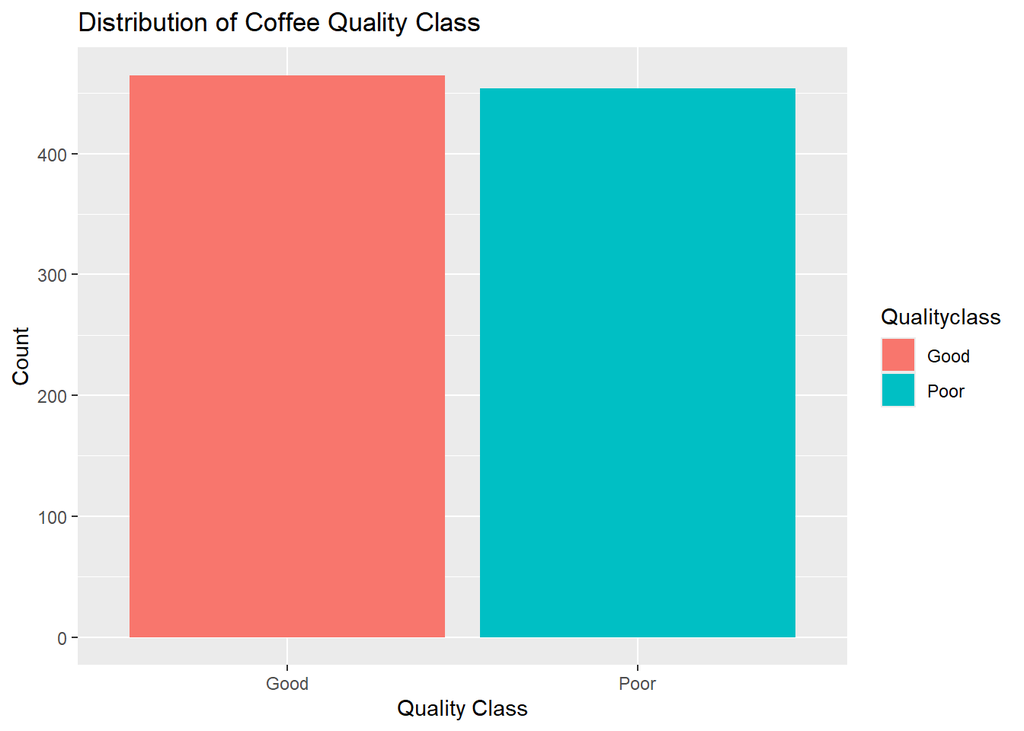

```r
coffee_clean %>%
  count(Qualityclass) %>%
  ggplot(aes(x = Qualityclass, y = n, fill = Qualityclass)) +
  geom_col() +
  labs(
    title = "Distribution of Coffee Quality Class",
    x = "Quality Class",
    y = "Count"
  )
```

This bar chart shows the number of coffee batches classified as Good and Poor. The two classes are relatively balanced, although the number of Good batches is slightly higher than the number of Poor batches. This suggests that class imbalance is unlikely to be a major issue in the later logistic GLM, since neither category overwhelmingly dominates the dataset.

## Aroma by quality class

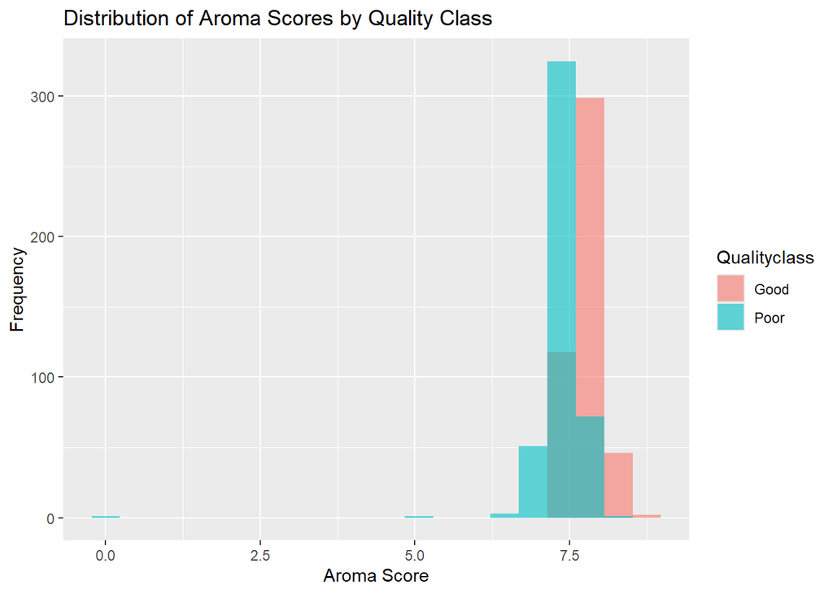

```r
ggplot(coffee_clean, aes(x = aroma, fill = Qualityclass)) +
  geom_histogram(alpha = 0.6, bins = 20, position = "identity") +
  labs(
    title = "Distribution of Aroma Scores by Quality Class",
    x = "Aroma Score",
    y = "Frequency"
  )
```

This histogram compares aroma scores across the two quality classes. The distribution for Good coffee is shifted slightly to the right, indicating that Good batches tend to have somewhat higher aroma scores than Poor batches. Although the two distributions overlap considerably, aroma still appears to contain useful information for distinguishing between the two classes and is therefore a plausible predictor in the later GLM.

## Flavor by quality class

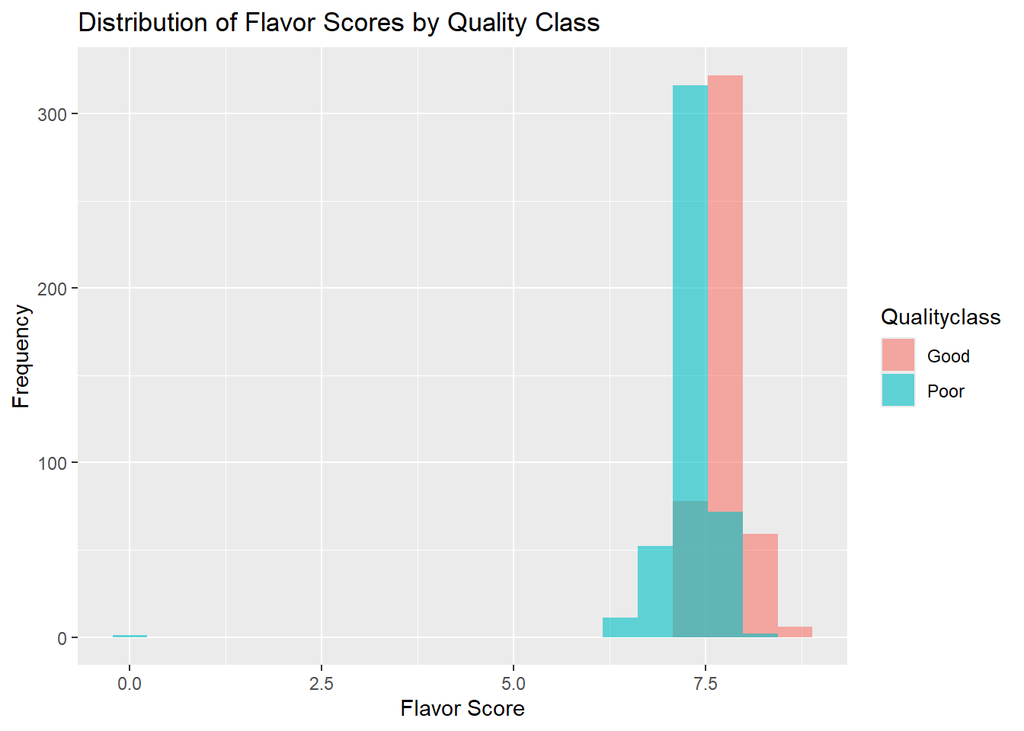

```r
ggplot(coffee_clean, aes(x = flavor, fill = Qualityclass)) +
  geom_histogram(alpha = 0.6, bins = 20, position = "identity") +
  labs(
    title = "Distribution of Flavor Scores by Quality Class",
    x = "Flavor Score",
    y = "Frequency"
  )
```

This plot compares flavor scores between Good and Poor coffee batches. Similar to aroma, the Good group appears to have a slightly higher concentration of observations at the upper end of the flavor scale. While there is substantial overlap between the two groups, the pattern suggests that higher flavor scores are associated with a greater probability of a batch being classified as Good, so flavor is likely to be an important explanatory variable.

## Acidity by quality class

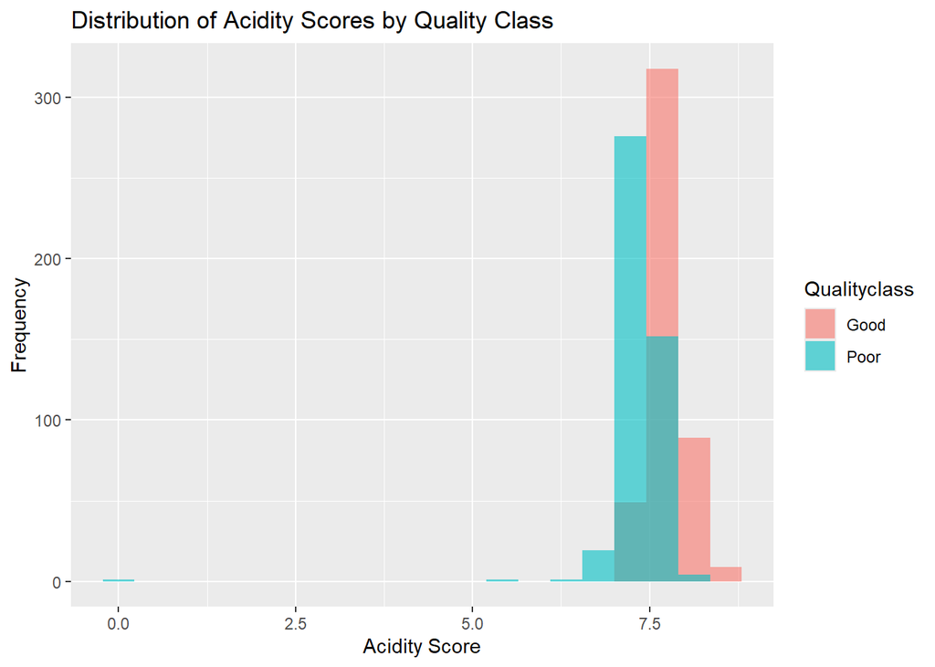

```r
ggplot(coffee_clean, aes(x = acidity, fill = Qualityclass)) +
  geom_histogram(alpha = 0.6, bins = 20, position = "identity") +
  labs(
    title = "Distribution of Acidity Scores by Quality Class",
    x = "Acidity Score",
    y = "Frequency"
  )
```

This histogram shows the distribution of acidity scores by quality class. The Good group appears to be centred at slightly higher acidity values, although the difference is less pronounced than for aroma or flavor. This suggests that acidity may still contribute to explaining coffee quality classification, but its effect may be weaker than some of the other sensory variables.

## Category two defects by quality class

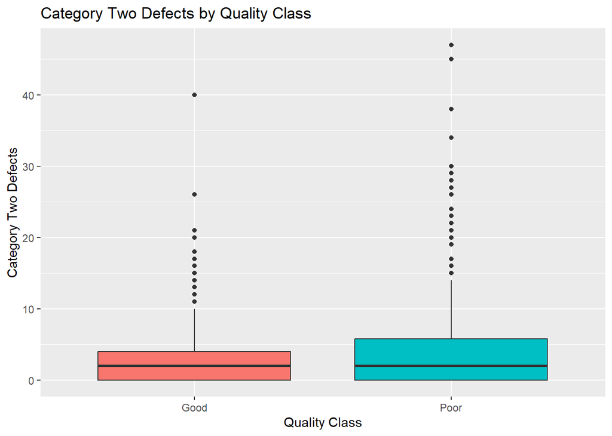

```r
ggplot(coffee_clean, aes(x = Qualityclass, y = category_two_defects, fill = Qualityclass)) +
  geom_boxplot() +
  labs(
    title = "Category Two Defects by Quality Class",
    x = "Quality Class",
    y = "Category Two Defects"
  ) +
  theme(legend.position = "none")
```

## Altitude and aroma

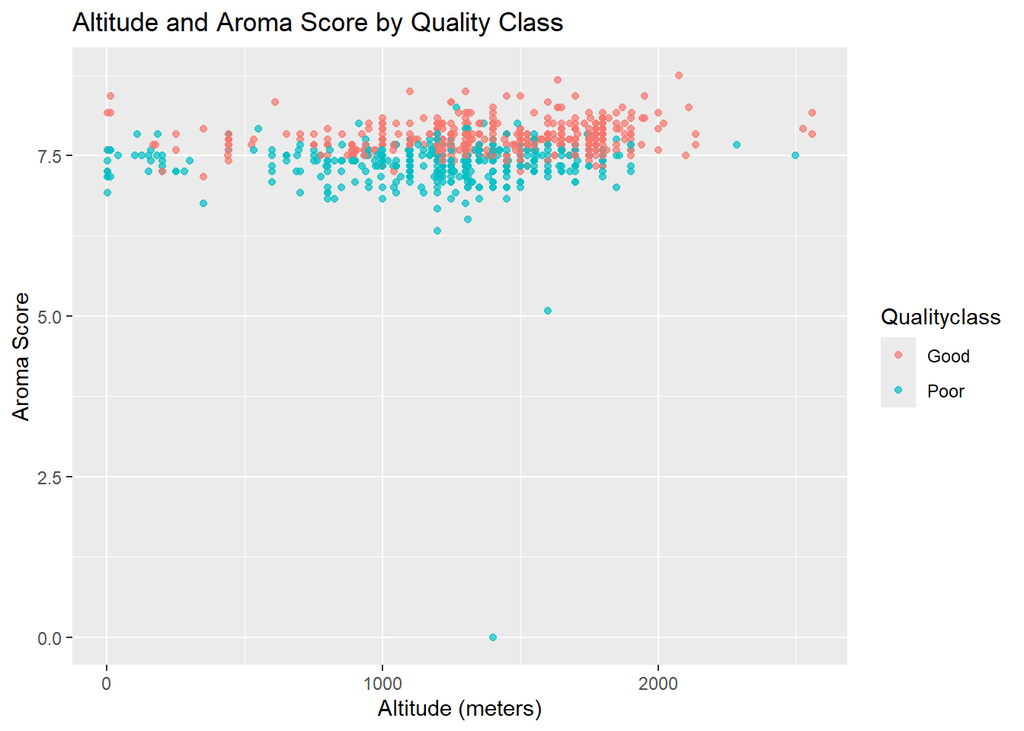

```r
ggplot(coffee_clean, aes(x = altitude_mean_meters, y = aroma, color = Qualityclass)) +
  geom_point(alpha = 0.7) +
  labs(
    title = "Altitude and Aroma Score by Quality Class",
    x = "Altitude (meters)",
    y = "Aroma Score"
  )
```

This scatterplot shows the relationship between altitude and aroma score, with points coloured by quality class. Most observations are concentrated within a similar altitude range, and the association between altitude and aroma does not appear strongly linear. However, Good batches tend to cluster at slightly higher aroma values across much of the altitude range. This suggests that altitude may provide some additional information, although its role is likely to be weaker and less direct than that of the sensory variables.

## Correlation analysis

```r
coffee_clean %>%
  select(aroma, flavor, acidity, altitude_mean_meters, category_two_defects) %>%
  cor(use = "complete.obs")
```

```
                          aroma     flavor    acidity altitude_mean_meters
aroma                 1.0000000  0.8324107  0.7558921          0.157128989
flavor                0.8324107  1.0000000  0.8415577          0.139187696
acidity               0.7558921  0.8415577  1.0000000          0.180694674
altitude_mean_meters  0.1571290  0.1391877  0.1806947          1.000000000
category_two_defects -0.1421449 -0.1864363 -0.1244330         -0.008705905
                     category_two_defects
aroma                        -0.142144893
flavor                       -0.186436330
acidity                      -0.124433005
altitude_mean_meters         -0.008705905
category_two_defects          1.000000000
```

The correlation matrix summarises the relationships among the main numeric variables. Aroma, flavor and acidity are moderately to strongly positively correlated, which is expected because these sensory measures reflect related aspects of coffee quality. By contrast, altitude and category two defects show much weaker relationships with the sensory variables, suggesting that they may capture different dimensions of coffee production and quality. This is useful for the later GLM, as it indicates that some predictors may contain overlapping information while others may contribute more distinct explanatory value.

Overall, the exploratory analysis suggests that sensory variables, particularly aroma, flavor and acidity, differ between coffee batches classified as Good and Poor. Among these, aroma and flavor appear to show the clearest separation, while acidity shows a weaker but still noticeable difference. In addition, higher defect counts are more common among Poor batches, and altitude may provide some additional contextual information even though its relationship with quality appears less direct. These findings suggest that both sensory and production-related variables should be considered in the later GLM modelling the probability that a coffee batch is classified as Good rather than Poor.